# Case study 1: Study ST000915

Kumari Sonal Choudhary

09/04/2020

## MetENP

MetENP is a R package that enables detection of significant metabolites from metabolite information (names or names and concentration along with metadata information) and provides

Enrichment score of metabolite class, Maps to pathway of the species of choice, Calculate enrichment score of pathways, Plots the pathways and shows the metabolite increase or decrease Gets gene info, reaction info, enzyme info For more info, check out the vignette.

```r
#suppressMessages(install.packages("devtools"))
```

```r
#library("devtools")
```

MetENP package depends on following Bioconductor packages to function properly: KEGGREST, KEGGgraph, pathview and KEGG.db. You may need to install these via:

if (!requireNamespace(“BiocManager”, quietly = TRUE)) install.packages(“BiocManager”)  
BiocManager::install(“KEGGREST”) BiocManager::install(“KEGGgraph”) BiocManager::install(“pathview”) BiocManager::install(“KEGG.db”)

## Proceed with installation

If this steps gives error: Install other dependencies and then try installing again: plyr,dplyr,tidyr,purrr,tidygraph,reshape2,ggplot2,ggrepel, igraph,ggraph,httr,stringr,jsonlite,rjson,tidyverse,magrittr

```r
library(MetENP)
```

#### If you do not wish to install, alternatively, download from github() and load libraries

```r
suppressMessages(library(plyr))
suppressMessages(library(dplyr))
suppressMessages(library(tidyr))
suppressMessages(library(sjmisc))
suppressMessages(library(tidygraph))
suppressMessages(library(KEGGREST))
suppressMessages(library(KEGGgraph))
suppressMessages(library(KEGG.db))
suppressMessages(library(pathview))
suppressMessages(library(reshape2))
suppressMessages(library(ggplot2))
suppressMessages(library(ggrepel))
suppressMessages(library(igraph))
suppressMessages(library(ggraph))
suppressMessages(library(httr))
suppressMessages(library(stringr))
suppressMessages(library(jsonlite))
suppressMessages(library(rjson))
suppressMessages(library(tidyverse))
suppressMessages(library(curl))
```

And load all the function. Please note this step is needed only when you do not wish to download or are hving difficulty in downloading the package

```r
source('C:/Users/bioso/Documents/MetENP/R/compoundinfo.R')
source('C:/Users/bioso/Documents/MetENP/R/anova_ana.R')
source('C:/Users/bioso/Documents/MetENP/R/met_pathways.R')
source('C:/Users/bioso/Documents/MetENP/R/mapspspath.R')
source('C:/Users/bioso/Documents/MetENP/R/metclassenrichment.R')
source('C:/Users/bioso/Documents/MetENP/R/metcountplot.R')
source('C:/Users/bioso/Documents/MetENP/R/getmwstudies.R')
#source('C:/Users/bioso/Documents/MetENP/R/comp_linkedto_pathways.R')
source('C:/Users/bioso/Documents/MetENP/R/path_enrichmentscore.R')
source('C:/Users/bioso/Documents/MetENP/R/pathinfo.R')
source('C:/Users/bioso/Documents/MetENP/R/plot_met_enrichment.R')
source('C:/Users/bioso/Documents/MetENP/R/plot_volcano.R')
source('C:/Users/bioso/Documents/MetENP/R/rxninfo.R')
source('C:/Users/bioso/Documents/MetENP/R/significant_met.R')
source('C:/Users/bioso/Documents/MetENP/R/significant_met_own.R')
source('C:/Users/bioso/Documents/MetENP/R/enzyme_gene_info.R')
source('C:/Users/bioso/Documents/MetENP/R/plot_heatmap.R')
source('C:/Users/bioso/Documents/MetENP/R/plot_pathway_networks.R')
source('C:/Users/bioso/Documents/MetENP/R/react_substrate.R')
source('C:/Users/bioso/Documents/MetENP/R/dotplot_met_class_path.R')
source('C:/Users/bioso/Documents/MetENP/R/convert_refmet.R')
source('C:/Users/bioso/Documents/MetENP/R/map_keggid.R')
source('C:/Users/bioso/Documents/MetENP/R/partial_join.R')
source('C:/Users/bioso/Documents/MetENP/R/getExtension.R')
source('C:/Users/bioso/Documents/MetENP/R/separate_data.R')
```

Data can be fetched via study id from Metabolomics Workbench through getmwstudies. For metabolomics data, ‘data’ is used, for metadata, ‘factors’ is used. If users want to uoload their own data, please do at the bottom of the page ST000915 is the study of biomarkers of nonalcoholic fatty liver disease (NAFLD) progression.

```r
metdata = getmwstudies('ST000915', 'data')
knitr::kable(head(metdata))
```

| analysis_id | analysis_summary | metabolite_name | metabolite_id | refmet_name | NASH001 | NASH002 | NASH003 | NASH004 | NASH005 | NASH006 | NASH007 | NASH009 | NASH010 | NASH012 | NASH013 | NASH014 | NASH015 | NASH016 | NASH017 | NASH018 | NASH057 | NASH071 | NASH072 | NASH073 | NASH075 | NASH076 | NASH077 | NASH078 | NASH079 | … |
| --- | --- | --- | --- | --- | --- | --- | --- | --- | --- | --- | --- | --- | --- | --- | --- | --- | --- | --- | --- | --- | --- | --- | --- | --- | --- | --- | --- | --- | --- | --- |
| AN001485 | Core G Fatty acids/Eicosanoids | 10 HDoHE | ME230937 | 10-HDoHE | 0.00419 | 0.01396 | 0.00285 | 0.00705 | 0.00020 | 0.00471 | 0.00158 | 0.00463 | 0.00063 | 0.00740 | 0.00435 | 0.00763 | 0.01377 | 0.01151 | 0.00090 | 0.02084 | 0.00265 | 0.00022 | 0.00038 | 0.00189 | 0.00321 | 0.00533 | 0.00152 | 0.00150 | 0.00237 | … |
| AN001485 | Core G Fatty acids/Eicosanoids | 11,12-diHETrE | ME230961 | 11,12-DiHETrE | 0.01346 | 1.84739 | 0.63897 | 1.87466 | 0.21119 | 2.23019 | 0.29970 | 1.17290 | 0.25164 | 0.90318 | 0.90953 | 0.70945 | 0.43454 | 0.81423 | 0.73651 | 0.16733 | 0.27242 | 0.02657 | 0.01304 | 0.02329 | 0.05239 | 0.02907 | 0.06744 | 0.05461 | 0.05734 | … |
| AN001485 | Core G Fatty acids/Eicosanoids | 11,12-EET | ME230954 | 11,12-EpETrE | 0.20666 | 0.12915 | 0.18170 | 0.11368 | 0.06081 | 0.34385 | 0.04465 | 0.05223 | 0.04092 | 0.15712 | 0.24605 | 0.22513 | 0.33102 | 0.12221 | 0.15930 | 0.07123 | 0.12722 | 0.14079 | 0.03025 | 0.10854 | 0.26357 | 0.09159 | 0.35800 | 0.22358 | 0.11807 | … |
| AN001485 | Core G Fatty acids/Eicosanoids | 11b PGE2 | ME230914 | 11beta-PGE2 | 0.00048 | 0.00128 | NA | NA | NA | NA | NA | NA | NA | NA | NA | NA | NA | 0.00533 | NA | 0.00264 | NA | 0.00262 | 0.00693 | 0.00187 | 0.00078 | 0.00072 | NA | NA | 0.00277 | … |
| AN001485 | Core G Fatty acids/Eicosanoids | 11 HDoHE | ME230941 | 11-HDoHE | 0.00617 | 0.03174 | 0.00958 | 0.00593 | 0.00271 | 0.05614 | 0.00784 | 0.03434 | 0.00303 | 0.02391 | 0.00861 | 0.01333 | 0.03302 | 0.02120 | 0.01284 | 0.02260 | 0.01865 | 0.00433 | 0.00596 | 0.00903 | 0.00737 | 0.01596 | 0.00938 | 0.01685 | 0.00716 | … |
| AN001485 | Core G Fatty acids/Eicosanoids | 11-HEPE | ME230917 | 11-HEPE | 0.00642 | NA | 0.01625 | 0.02049 | 0.00115 | 0.01440 | 0.00628 | 0.03413 | NA | 0.01394 | 0.00608 | 0.02614 | 0.00429 | 0.03508 | 0.01276 | 0.00453 | 0.00936 | 0.00567 | 0.00041 | NA | 0.00119 | 0.00098 | 0.00035 | 0.00111 | 0.01423 | … |

Associate metabolomics data to the refmet class

```r
refmet_class= convert_refmet(metdata)
```

```r
metadata = getmwstudies('ST000915', 'factors')
knitr::kable(head(metadata))
```

| study_id | local_sample_id | subject_type | factors | Diagnosis |
| --- | --- | --- | --- | --- |
| ST000915 | NASH005 | Human clinical study | Diagnosis:Cirrhosis | Cirrhosis |
| ST000915 | NASH007 | Human clinical study | Diagnosis:Cirrhosis | Cirrhosis |
| ST000915 | NASH009 | Human clinical study | Diagnosis:Cirrhosis | Cirrhosis |
| ST000915 | NASH013 | Human clinical study | Diagnosis:Cirrhosis | Cirrhosis |
| ST000915 | NASH016 | Human clinical study | Diagnosis:Cirrhosis | Cirrhosis |
| ST000915 | NASH022 | Human clinical study | Diagnosis:Cirrhosis | Cirrhosis |

Find the factors you would want to compare. Multiple factors/experimental groups (independent variables) are formatted in multiple columns but you can get information on all the experimental groups by “factors” column. For t-test use the independent variables in the same column. For comparing multipe independent variables use anova by anova_ana function.

For ex: in this study, we want to compare Diagnosis experimental methods, so we will compare Cirrhosis and Normal samples

```r
unique(metadata$factors)
```

```
## [[1]]
## [1] "Diagnosis:Cirrhosis"
##
## [[2]]
## [1] "Diagnosis:NASH"
##
## [[3]]
## [1] "Diagnosis:Normal"
##
## [[4]]
## [1] "Diagnosis:Steatosis"
```

```r
### Find the analysis mode
unique(metdata$analysis_summary)
```

```
## [[1]]
## [1] "Core G Fatty acids/Eicosanoids"
##
## [[2]]
## [1] "Core J Sterols"
##
## [[3]]
## [1] "Core K Prenols/Cardiolipins"
##
## [[4]]
## [1] "Core E Neutral Lipids"
##
## [[5]]
## [1] "Core I Sphingolipids"
##
## [[6]]
## [1] "Core H Phospholipids"
```

### Find significant metabolites, run significance of all the analysis summary together. The analysis summary/modes you got in the previous section

Significant metabolites can be found by using significant_met function. The parameters are:

metabolomics_data: metabolomics data associated to refmet class

met_col: column with metabolite names

analysis_type: type of analysis ex-GCMS, HILIAC positive ion mode.

metadata: Metadata

factor1: first independent variable

factor2: second independent variable

factor_col: column name of the independent variables

sample_col: the column name having samples

p_adjust: Method for p value adjustment, i.e. “fdr”

normalization: method for normalization a) “half_of_min”: where the NAs are replaced by half of min values in the data b) “remove_NAs”: where Cols with NAs values are removed and c) “50percent”: where cols with more than 50% NAs values are removed

half_of_min is ideal when you wish to see which metabolites were present in either group. Very high fold change would mean it was present in either group.

In this example, we show significant metabolite filtered according to pvalue threshold of 0.05 and log2 fold change of 0.5, p adjust method of ‘fdr’ and we use the normalization method “50percent”

```r
stats_metabolites = significant_met(metabolomics_data=refmet_class, met_col="metabolite_name",analysis_type=c("Core G Fatty acids/Eicosanoids","Core J Sterols","Core K Prenols/Cardiolipins","Core E Neutral Lipids","Core I Sphingolipids","Core H Phospholipids"), metadata=metadata, factor1='Cirrhosis', factor2=c('Normal'), factor_col='Diagnosis',sample_col='local_sample_id', p_adjust='fdr',normalization="50percent")

sig_metabolites = stats_metabolites[which(stats_metabolites[,"pval"] <= 0.05&abs(stats_metabolites[,"log2Fold_change"])>0.5),]
knitr::kable(head(sig_metabolites))
```

|  | Metabolite | Cirrhosis_mean | Normal_mean | Fold_change | log2Fold_change | t_value | pval | padj | metabolite_id | refmet_name | super_class | main_class | sub_class | formula |
| --- | --- | --- | --- | --- | --- | --- | --- | --- | --- | --- | --- | --- | --- | --- |
| 5 | 11,12-EET | 0.0609060 | 0.1709519 | 2.8068154 | 1.488934 | -2.946309 | 0.0055361 | 0.1384028 | ME230954 | 11,12-EpETrE | Fatty Acyls | Eicosanoids | EpETrE | C20H32O3 |
| 6 | 12-HEPE | 0.00945950 | 0.03728742 | 3.9417961 | 1.978853 | -2.846260 | 0.0077250 | 0.1448446 | ME230939 | 12-HEPE | Fatty Acyls | Eicosanoids | HEPE | C20H30O3 |
| 7 | 12-HETE | 0.109529 | 0.255101 | 2.3290727 | 1.219756 | -3.994515 | 0.0002766 | 0.0207450 | ME230938 | 12-HETE | Fatty Acyls | Eicosanoids | HETE | C20H32O3 |
| 12 | 14 HDoHE | 0.00825450 | 0.02744806 | 3.3252238 | 1.733451 | -3.316098 | 0.0020102 | 0.0753841 | ME230940 | 14-HDoHE | Fatty Acyls | Docosanoids | Docosanoids | C22H32O3 |
| 14 | 14,15-EET | 0.1171725 | 0.3177545 | 2.7118522 | 1.439278 | -2.236125 | 0.0318876 | 0.2385268 | ME230955 | 14,15-EpETrE | Fatty Acyls | Eicosanoids | EpETrE | C20H32O3 |
| 17 | 15-HETrE | 0.04673850 | 0.01022645 | 0.2188014 | -2.192306 | 2.425914 | 0.0250871 | 0.2090595 | ME230935 | 15-HeTrE | Fatty Acyls | Eicosanoids | ETrE | C20H34O3 |

### Significant Metabolites can be visualized via Volcano Plot

We will use the same thresholds as used for determining significant metabolites

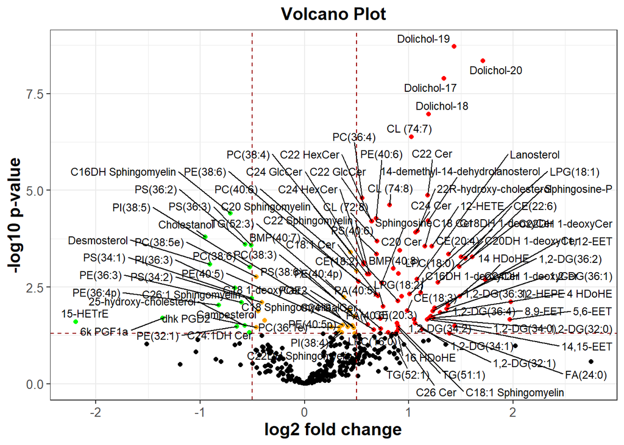

```r
plot_volcano(stats_metabolites, thres_pval= 0.05,thres_log2foldchange = 0.5, TRUE)
```

### Map metabolite class of the significant metabolites utilzing refmet classification in Metabolomics Workbench

This function maps metabolite to metabolite class

In this example, we will go forward with significant metabolite obtained by t-test

```r
sig_metabolites_kegg_id= map_keggid(sig_metabolites)
knitr::kable(head(sig_metabolites_kegg_id))
```

| refmet_name | Exact mass | KEGG ID | Metabolite | Cirrhosis_mean | Normal_mean | Fold_change | log2Fold_change | t_value | pval | padj | metabolite_id | super_class | main_class | sub_class | formula |
| --- | --- | --- | --- | --- | --- | --- | --- | --- | --- | --- | --- | --- | --- | --- | --- |
| 1-DeoxyCer 18:0;O2/16:0 | 523.5328 |  | C16DH 1-deoxyCer | 0.05623685 | 0.12178748 | 2.165617 | 1.114778 | -3.028001 | 0.0044114 | 0.0251708 | ME231305 | Sphingolipids | Ceramides | 1-deoxyCer | C34H69NO2 |
| 1-DeoxyCer 18:0;O2/18:0 | 551.5641 |  | C18DH 1-deoxyCer | 0.0906803 | 0.2566956 | 2.830776 | 1.501197 | -3.826879 | 0.0005220 | 0.0056713 | ME231306 | Sphingolipids | Ceramides | 1-deoxyCer | C36H73NO2 |
| 1-DeoxyCer 18:0;O2/20:0 | 579.5954 |  | C20DH 1-deoxyCer | 0.0723488 | 0.1756429 | 2.427724 | 1.279604 | -3.268230 | 0.0023663 | 0.0150818 | ME231307 | Sphingolipids | Ceramides | 1-deoxyCer | C38H77NO2 |
| 1-DeoxyCer 18:0;O2/22:0 | 607.6267 |  | C22DH 1-deoxyCer | 0.1513816 | 0.4227716 | 2.792754 | 1.481689 | -3.604410 | 0.0009458 | 0.0076456 | ME231308 | Sphingolipids | Ceramides | 1-deoxyCer | C40H81NO2 |
| 1-DeoxyCer 18:0;O2/24:0 | 635.6580 |  | C24DH 1-deoxyCer | 0.1177141 | 0.3056195 | 2.596286 | 1.376450 | -2.746084 | 0.0091800 | 0.0468664 | ME231310 | Sphingolipids | Ceramides | 1-deoxyCer | C42H85NO2 |
| 1,2-DG 32:0 | 568.5067 | C00641 | 1,2-DG(32:0) | 210.0625 | 479.9210 | 2.284658 | 1.191978 | -2.410346 | 0.0200254 | 0.1066535 | ME231196 | Glycerolipids | Diradylglycerols | DAG | C35H68O5 |

#### Check all your significant metabolites have not been assigned metabolite class

```r
setdiff(sig_metabolites$refmet_name, sig_metabolites_kegg_id$refmet_name)
```

```
## character(0)
```

### Count metabolites in each of the metabolite class and plotting

You may choose from sub_class, main_class and super_class

```r
count_changes = metcountplot(df_metclass=sig_metabolites_kegg_id, metclass='sub_class', plotting=TRUE, thres_logfC = 0.5)
```

To see the Plot

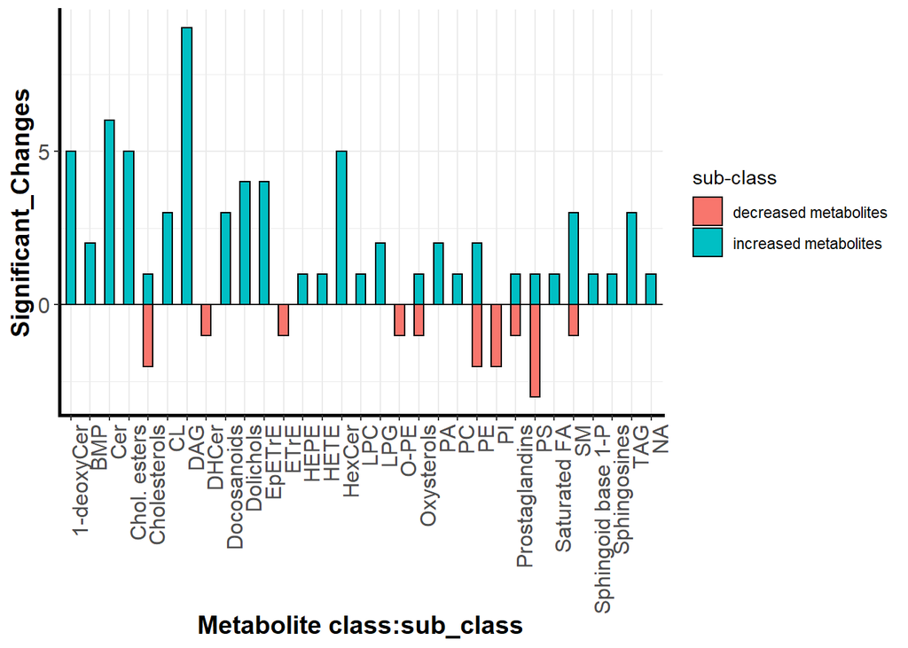

```r
count_changes$plotimg
```

### Enrichment class score

Calculate the enrichment score of each metabolite class. Enrichment score is calculated through hypergeometric method. One can specify the no. of significant metabolites in a class while calculating the enrichment score. We advice to use the number of mtabolites in each class as 3 or more. But if someone just wants to know the enrichment score and rest of the information of all the metabolites, then they can choose the number as 1.

```r
metenrichment = metclassenrichment(df_metclass=sig_metabolites_kegg_id,refmet_class, metclass="sub_class",enrich_stats="HG",no=3)
knitr::kable(head(metenrichment))
```

| refmet_name | Exact mass | KEGG ID | Metabolite | Cirrhosis_mean | Normal_mean | Fold_change | log2Fold_change | t_value | pval | padj | metabolite_id | super_class | main_class | sub_class | formula | HG p-value |
| --- | --- | --- | --- | --- | --- | --- | --- | --- | --- | --- | --- | --- | --- | --- | --- | --- |
| 1-DeoxyCer 18:0;O2/16:0 | 523.5328 |  | C16DH 1-deoxyCer | 0.05623685 | 0.12178748 | 2.165617 | 1.114778 | -3.028001 | 0.0044114 | 0.0251708 | ME231305 | Sphingolipids | Ceramides | 1-deoxyCer | C34H69NO2 | 0.0003487 |
| 1-DeoxyCer 18:0;O2/18:0 | 551.5641 |  | C18DH 1-deoxyCer | 0.0906803 | 0.2566956 | 2.830776 | 1.501197 | -3.826879 | 0.0005220 | 0.0056713 | ME231306 | Sphingolipids | Ceramides | 1-deoxyCer | C36H73NO2 | 0.0004793 |
| 1-DeoxyCer 18:0;O2/20:0 | 579.5954 |  | C20DH 1-deoxyCer | 0.0723488 | 0.1756429 | 2.427724 | 1.279604 | -3.268230 | 0.0023663 | 0.0150818 | ME231307 | Sphingolipids | Ceramides | 1-deoxyCer | C38H77NO2 | 0.0004793 |
| 1-DeoxyCer 18:0;O2/22:0 | 607.6267 |  | C22DH 1-deoxyCer | 0.1513816 | 0.4227716 | 2.792754 | 1.481689 | -3.604410 | 0.0009458 | 0.0076456 | ME231308 | Sphingolipids | Ceramides | 1-deoxyCer | C40H81NO2 | 0.0004793 |
| 1-DeoxyCer 18:0;O2/24:0 | 635.6580 |  | C24DH 1-deoxyCer | 0.1177141 | 0.3056195 | 2.596286 | 1.376450 | -2.746084 | 0.0091800 | 0.0468664 | ME231310 | Sphingolipids | Ceramides | 1-deoxyCer | C42H85NO2 | 0.0004793 |
| 1,2-DG 32:0 | 568.5067 | C00641 | 1,2-DG(32:0) | 210.0625 | 479.9210 | 2.284658 | 1.191978 | -2.410346 | 0.0200254 | 0.1066535 | ME231196 | Glycerolipids | Diradylglycerols | DAG | C35H68O5 | 0.0000078 |

#### Plot the enrichment score via function plot_met_enrichment

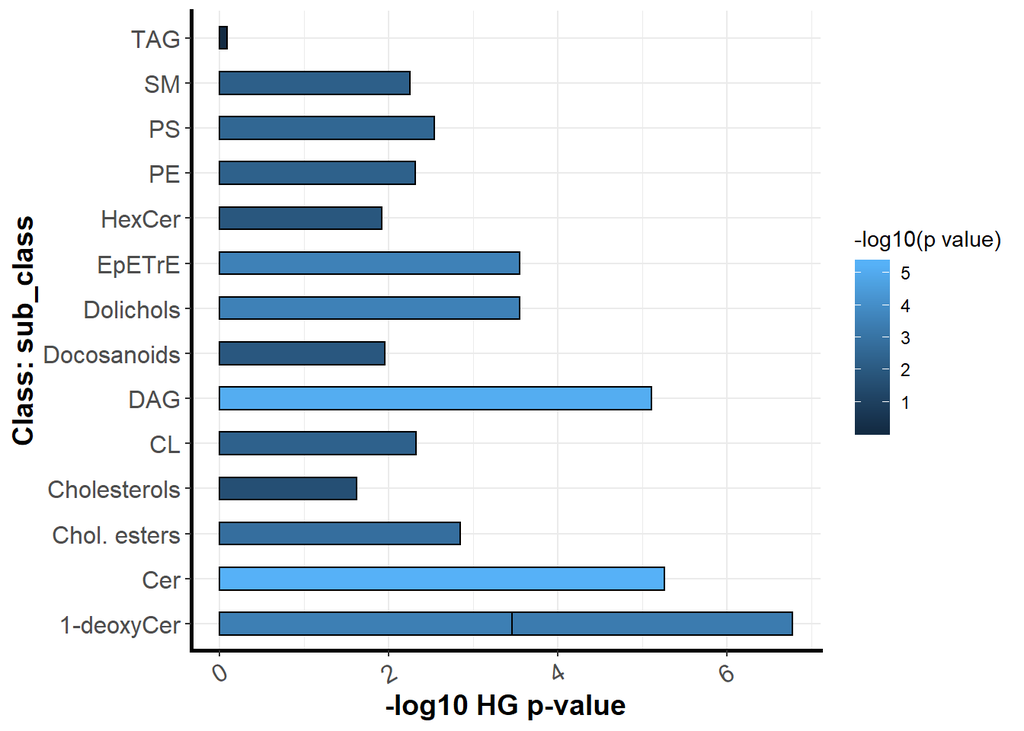

```r
plot_met_enrichment(metenrichment, "sub_class","HG", no=3)
```

### Check the pathways with reactions of all the significant metabolites in Species specific manner.

First parameter is the metenrichment dataframe, while second parameter is the species code from KEGG

Here the subject species is Homo sapiens, and the KEGG species annotation for KEGG is ‘hsa’

```r
met_path = met_pathways(df_metenrichment = metenrichment, 'hsa')
knitr::kable(head(met_path))
```

| rxn | refmet_name | Exact mass | KEGG ID | Metabolite | Cirrhosis_mean | Normal_mean | Fold_change | log2Fold_change | t_value | pval | padj | metabolite_id | super_class | main_class | sub_class | formula | HG p-value | Rxn_name | PATHWAY | pathway_id | sps_path_id |
| --- | --- | --- | --- | --- | --- | --- | --- | --- | --- | --- | --- | --- | --- | --- | --- | --- | --- | --- | --- | --- | --- |
| R01312 | 1,2-DG 34:1 | 594.5223 | C00641 | 1,2-DG(34:1) | 601.8775 | 1256.7161 | 2.087993 | 1.062117 | -2.284839 | 0.0268619 | 0.1137014 | ME231202 | Glycerolipids | Diradylglycerols | DAG | C37H70O5 | 7.8e-06 | Phosphatidylcholine cholinephosphohydrolase | Glycerophospholipid metabolism | rn00564 | hsa00564 |
| R01312 | 1,2-DG 36:4 | 616.5067 | C00641 | 1,2-DG(36:4) | 165.5750 | 383.1855 | 2.314271 | 1.210558 | -2.453312 | 0.0180560 | 0.1066535 | ME231210 | Glycerolipids | Diradylglycerols | DAG | C39H68O5 | 7.8e-06 | Phosphatidylcholine cholinephosphohydrolase | Glycerophospholipid metabolism | rn00564 | hsa00564 |
| R01312 | 1,2-DG 32:1 | 566.4910 | C00641 | 1,2-DG(32:1) | 210.1550 | 459.3081 | 2.185568 | 1.128008 | -2.126083 | 0.0387661 | 0.1308355 | ME231195 | Glycerolipids | Diradylglycerols | DAG | C35H66O5 | 7.8e-06 | Phosphatidylcholine cholinephosphohydrolase | Glycerophospholipid metabolism | rn00564 | hsa00564 |
| R01312 | 1,2-DG 34:2 | 592.5067 | C00641 | 1,2-DG(34:2) | 485.6675 | 1006.3597 | 2.072117 | 1.051105 | -2.372477 | 0.0217257 | 0.1066535 | ME231201 | Glycerolipids | Diradylglycerols | DAG | C37H68O5 | 7.8e-06 | Phosphatidylcholine cholinephosphohydrolase | Glycerophospholipid metabolism | rn00564 | hsa00564 |
| R01312 | 1,2-DG 32:0 | 568.5067 | C00641 | 1,2-DG(32:0) | 210.0625 | 479.9210 | 2.284658 | 1.191978 | -2.410346 | 0.0200254 | 0.1066535 | ME231196 | Glycerolipids | Diradylglycerols | DAG | C35H68O5 | 7.8e-06 | Phosphatidylcholine cholinephosphohydrolase | Glycerophospholipid metabolism | rn00564 | hsa00564 |
| R01312 | 1,2-DG 36:2 | 620.5380 | C00641 | 1,2-DG(36:2) | 408.4525 | 968.4145 | 2.370935 | 1.245456 | -2.651684 | 0.0110130 | 0.1023686 | ME231212 | Glycerolipids | Diradylglycerols | DAG | C39H72O5 | 7.8e-06 | Phosphatidylcholine cholinephosphohydrolase | Glycerophospholipid metabolism | rn00564 | hsa00564 |

Find metabolites for which no pathways were registered in Kegg and/or no kegg id was found

```r
setdiff(metenrichment$Metabolite,unique(met_path$Metabolite))
```

```
##  [1] "C16DH 1-deoxyCer" "C18DH 1-deoxyCer" "C20DH 1-deoxyCer" "C22DH 1-deoxyCer"
##  [5] "C24DH 1-deoxyCer" "14 HDoHE"         "16 HDoHE"         "4 HDoHE"
##  [9] "CE(18:2)"         "CE(18:3)"         "CE(20:3)"         "CE(20:4)"
## [13] "CE(22:6)"         "CL (72:8)"        "CL (74:7)"        "CL (74:8)"
## [17] "Cholestanol"      "Dolichol-17"      "Dolichol-18"      "Dolichol-19"
## [21] "Dolichol-20"
```

### Get pathway enrichment sore.

Once we have the pathway information, we can calculate enrichment score of pathways. Again, here i have used hypergeometric score.

There are two ways to calculate in MetENP. If users want to calculate based on total no of metabolites detected in the study N= the total number of metabolites in a study, which can be retrieved from refmet_class dataframe.

Instead, if the users want to calculate HG score such that they can compare two studies, the N is the total no. of cmpds linked to kegg pathway (this is the step which might take long), so I advice to run the script comp_linkedto_pathways() just the first time or after 6 months or so, if desired to run the pipeline again. save the result from comp_linkedto_pathways() and load it. Loading from saved file would save time for another analysis with another study.

L = all significant metabolites detected in a study M= all significant metabolites detected in a pathway K = all metabolites detected in a pathway

phyper(M,L, N-L, K)

This function also utilizes korg dataset from pathview package.

In this example, the background set N is the total number of metabolites in a study

```r
load('C:/Users/bioso/Documents/MetENP/data/ls_path.RData')
load('C:/Users/bioso/Documents/MetENP/data/korg.RData')
kegg_es = path_enrichmentscore(met_path,sig_metabolite_kegg_id=sig_metabolite_kegg_id,ls_path=ls_path,refmet_class=refmet_class,sps='hsa',padj='fdr', kegg_comp_path=FALSE)
knitr::kable(head(kegg_es))
```

|  | Pathway name | No.of mets in study | Total_no._of_comps_in_pathway | pathway_HG p-value | Padjust |
| --- | --- | --- | --- | --- | --- |
| 110 | Arachidonic acid metabolism | 4 | 75 | 0.9991730 | 0.9991730 |
| 13 | Glycerolipid metabolism | 12 | 38 | 0.0084694 | 0.0190562 |
| 11 | Glycerophospholipid metabolism | 17 | 52 | 0.0009973 | 0.0029919 |
| 16 | Glycine, serine and threonine metabolism | 4 | 50 | 0.9705819 | 0.9991730 |
| 19 | Glycosylphosphatidylinositol (GPI)-anchor biosynthesis | 13 | 16 | 0.0000000 | 0.0000000 |
| 17 | Inositol phosphate metabolism | 9 | 47 | 0.3070207 | 0.3947409 |

### Plot pathway network

The pathway network is such that it shows metabolites that are connected to different pathways and same metabolite in different pathway. Color of nodes of metabolites are according to the fold change of metabolites (low expression in green and high in red) and size of pathway nodes (square nodes) are according to the number of branches (meaning no of metabolites). All metabolite are written in blue

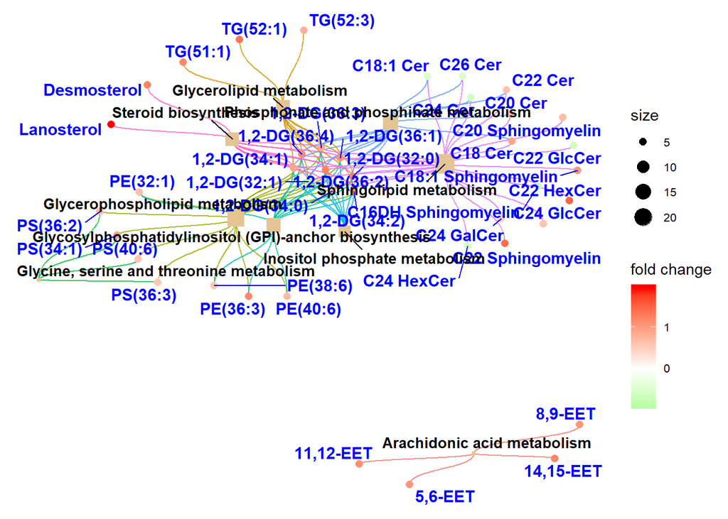

```r
plot_pathway_networks (met_path,kegg_es, TRUE)
```

### Heatmap

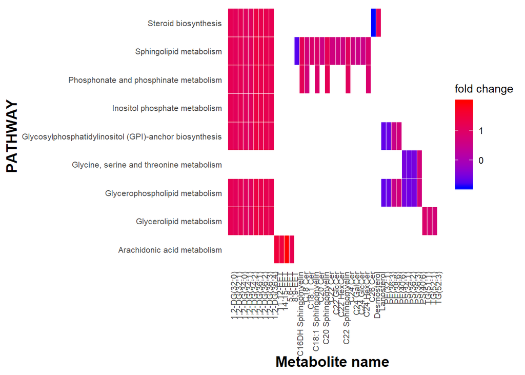

```r
plot_heatmap(met_path)
```

### Dotplot

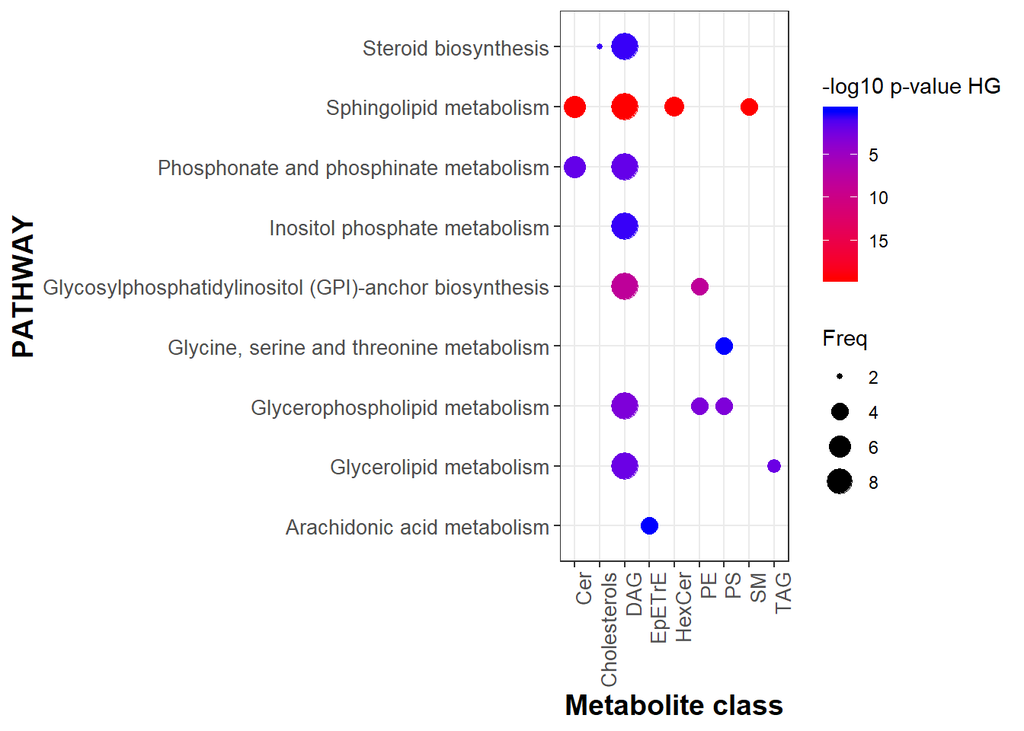

```r
dotplot_met_class_path (met_path, kegg_es,"sub_class")
```

### Get the gene and enzyme info

Here we get the information of genes involved in enriched pathways for specified organism

```r
met_gene_info = enzyme_gene_info (metenrichment, "hsa","sub_class")
knitr::kable(head(met_gene_info))
```

| orthology_id | ORTHOLOGY | gene_id | gene_name | DEFINITION | ORGANISM | PATHWAY | DBLINKS | MOTIF | rxn | Metabolite | KEGG ID | sub_class | Rxn_name | RCLASS | EQUATION | EQUATION_more | ENZYME |
| --- | --- | --- | --- | --- | --- | --- | --- | --- | --- | --- | --- | --- | --- | --- | --- | --- | --- |
| K00551 | phosphatidylethanolamine/phosphatidyl-N-methylethanolamine N-methyltransferase [EC:2.1.1.17 2.1.1.71] | 10400 | PEMT, PEAMT, PEMPT, PEMT2, PLMT, PNMT | (RefSeq) phosphatidylethanolamine N-methyltransferase | Homo sapiens (human) | c(hsa00564 = “Glycerophospholipid metabolism”, hsa01100 = “Metabolic pathways”) | c(“NCBI-GeneID: 10400”, “NCBI-ProteinID: NP_009100”, “OMIM: 602391”, “HGNC: 8830”, “Ensembl: ENSG00000133027”, “Vega: OTTHUMG00000059290”, “Pharos: Q9UBM1(Tbio)”, “UniProt: Q9UBM1”) | Pfam: PEMT Herpes_UL74 | R02056 | PE(40:6) | C00350 | PE | S-adenosyl-L-methionine:phosphatidylethanolamine N-methyltransferase | c(“RC00003 C00019_C00021”, “RC00060 C00350_C01241”) | C00019 + C00350 <=> C00021 + C01241 | S-Adenosyl-L-methionine + Phosphatidylethanolamine <=> S-Adenosyl-L-homocysteine + Phosphatidyl-N-methylethanolamine | 2.1.1.17 |
| K00551 | phosphatidylethanolamine/phosphatidyl-N-methylethanolamine N-methyltransferase [EC:2.1.1.17 2.1.1.71] | 10400 | PEMT, PEAMT, PEMPT, PEMT2, PLMT, PNMT | (RefSeq) phosphatidylethanolamine N-methyltransferase | Homo sapiens (human) | c(hsa00564 = “Glycerophospholipid metabolism”, hsa01100 = “Metabolic pathways”) | c(“NCBI-GeneID: 10400”, “NCBI-ProteinID: NP_009100”, “OMIM: 602391”, “HGNC: 8830”, “Ensembl: ENSG00000133027”, “Vega: OTTHUMG00000059290”, “Pharos: Q9UBM1(Tbio)”, “UniProt: Q9UBM1”) | Pfam: PEMT Herpes_UL74 | R02056 | PE(36:3) | C00350 | PE | S-adenosyl-L-methionine:phosphatidylethanolamine N-methyltransferase | c(“RC00003 C00019_C00021”, “RC00060 C00350_C01241”) | C00019 + C00350 <=> C00021 + C01241 | S-Adenosyl-L-methionine + Phosphatidylethanolamine <=> S-Adenosyl-L-homocysteine + Phosphatidyl-N-methylethanolamine | 2.1.1.17 |
| K00551 | phosphatidylethanolamine/phosphatidyl-N-methylethanolamine N-methyltransferase [EC:2.1.1.17 2.1.1.71] | 10400 | PEMT, PEAMT, PEMPT, PEMT2, PLMT, PNMT | (RefSeq) phosphatidylethanolamine N-methyltransferase | Homo sapiens (human) | c(hsa00564 = “Glycerophospholipid metabolism”, hsa01100 = “Metabolic pathways”) | c(“NCBI-GeneID: 10400”, “NCBI-ProteinID: NP_009100”, “OMIM: 602391”, “HGNC: 8830”, “Ensembl: ENSG00000133027”, “Vega: OTTHUMG00000059290”, “Pharos: Q9UBM1(Tbio)”, “UniProt: Q9UBM1”) | Pfam: PEMT Herpes_UL74 | R02056 | PE(38:6) | C00350 | PE | S-adenosyl-L-methionine:phosphatidylethanolamine N-methyltransferase | c(“RC00003 C00019_C00021”, “RC00060 C00350_C01241”) | C00019 + C00350 <=> C00021 + C01241 | S-Adenosyl-L-methionine + Phosphatidylethanolamine <=> S-Adenosyl-L-homocysteine + Phosphatidyl-N-methylethanolamine | 2.1.1.17 |
| K00551 | phosphatidylethanolamine/phosphatidyl-N-methylethanolamine N-methyltransferase [EC:2.1.1.17 2.1.1.71] | 10400 | PEMT, PEAMT, PEMPT, PEMT2, PLMT, PNMT | (RefSeq) phosphatidylethanolamine N-methyltransferase | Homo sapiens (human) | c(hsa00564 = “Glycerophospholipid metabolism”, hsa01100 = “Metabolic pathways”) | c(“NCBI-GeneID: 10400”, “NCBI-ProteinID: NP_009100”, “OMIM: 602391”, “HGNC: 8830”, “Ensembl: ENSG00000133027”, “Vega: OTTHUMG00000059290”, “Pharos: Q9UBM1(Tbio)”, “UniProt: Q9UBM1”) | Pfam: PEMT Herpes_UL74 | R02056 | PE(32:1) | C00350 | PE | S-adenosyl-L-methionine:phosphatidylethanolamine N-methyltransferase | c(“RC00003 C00019_C00021”, “RC00060 C00350_C01241”) | C00019 + C00350 <=> C00021 + C01241 | S-Adenosyl-L-methionine + Phosphatidylethanolamine <=> S-Adenosyl-L-homocysteine + Phosphatidyl-N-methylethanolamine | 2.1.1.17 |
| K00720 | ceramide glucosyltransferase [EC:2.4.1.80] | 7357 | UGCG, GCS, GLCT1 | (RefSeq) UDP-glucose ceramide glucosyltransferase | Homo sapiens (human) | c(hsa00600 = “Sphingolipid metabolism”, hsa01100 = “Metabolic pathways”) | c(“NCBI-GeneID: 7357”, “NCBI-ProteinID: NP_003349”, “OMIM: 602874”, “HGNC: 12524”, “Ensembl: ENSG00000148154”, “Vega: OTTHUMG00000020498”, “Pharos: Q16739(Tclin)”, “UniProt: Q16739 A0A024R157”) | Pfam: Glyco_transf_21 Glyco_tranf_2_3 Glyco_trans_2_3 Glycos_transf_2 Chitin_synth_2 | R06275 | C22 Cer | C00195 | Cer | NULL | NULL | G10608 + C00195 <=> G10619 + G10238 | UDP-D-glucose + N-Acylsphingosine <=> UDP + Glucosylceramide | 2.4.1.80 |
| K00720 | ceramide glucosyltransferase [EC:2.4.1.80] | 7357 | UGCG, GCS, GLCT1 | (RefSeq) UDP-glucose ceramide glucosyltransferase | Homo sapiens (human) | c(hsa00600 = “Sphingolipid metabolism”, hsa01100 = “Metabolic pathways”) | c(“NCBI-GeneID: 7357”, “NCBI-ProteinID: NP_003349”, “OMIM: 602874”, “HGNC: 12524”, “Ensembl: ENSG00000148154”, “Vega: OTTHUMG00000020498”, “Pharos: Q16739(Tclin)”, “UniProt: Q16739 A0A024R157”) | Pfam: Glyco_transf_21 Glyco_tranf_2_3 Glyco_trans_2_3 Glycos_transf_2 Chitin_synth_2 | R01497 | C22 Cer | C00195 | Cer | UDP-glucose:N-acylsphingosine D-glucosyltransferase | c(“RC00005 C00015_C00029”, “RC00059 C00195_C01190”) | C00029 + C00195 <=> C00015 + C01190 | UDP-glucose + N-Acylsphingosine <=> UDP + Glucosylceramide | 2.4.1.80 |

#### Get the information if metabolite is a reactant or substrate

```r
rclass_info = react_substrate(met_gene_info)
knitr::kable(head(rclass_info))
```

| orthology_id | ORTHOLOGY | gene_id | gene_name | DEFINITION | ORGANISM | PATHWAY | DBLINKS | MOTIF | rxn | Metabolite | KEGG ID | sub_class | Rxn_name | RCLASS | EQUATION | EQUATION_more | ENZYME | reactant_product |
| --- | --- | --- | --- | --- | --- | --- | --- | --- | --- | --- | --- | --- | --- | --- | --- | --- | --- | --- |
| K00551 | phosphatidylethanolamine/phosphatidyl-N-methylethanolamine N-methyltransferase [EC:2.1.1.17 2.1.1.71] | 10400 | PEMT, PEAMT, PEMPT, PEMT2, PLMT, PNMT | (RefSeq) phosphatidylethanolamine N-methyltransferase | Homo sapiens (human) | c(hsa00564 = “Glycerophospholipid metabolism”, hsa01100 = “Metabolic pathways”) | c(“NCBI-GeneID: 10400”, “NCBI-ProteinID: NP_009100”, “OMIM: 602391”, “HGNC: 8830”, “Ensembl: ENSG00000133027”, “Vega: OTTHUMG00000059290”, “Pharos: Q9UBM1(Tbio)”, “UniProt: Q9UBM1”) | Pfam: PEMT Herpes_UL74 | R02056 | PE(40:6) | C00350 | PE | S-adenosyl-L-methionine:phosphatidylethanolamine N-methyltransferase | c(“RC00003 C00019_C00021”, “RC00060 C00350_C01241”) | C00019 + C00350 <=> C00021 + C01241 | S-Adenosyl-L-methionine + Phosphatidylethanolamine <=> S-Adenosyl-L-homocysteine + Phosphatidyl-N-methylethanolamine | 2.1.1.17 | Substrate |
| K00551 | phosphatidylethanolamine/phosphatidyl-N-methylethanolamine N-methyltransferase [EC:2.1.1.17 2.1.1.71] | 10400 | PEMT, PEAMT, PEMPT, PEMT2, PLMT, PNMT | (RefSeq) phosphatidylethanolamine N-methyltransferase | Homo sapiens (human) | c(hsa00564 = “Glycerophospholipid metabolism”, hsa01100 = “Metabolic pathways”) | c(“NCBI-GeneID: 10400”, “NCBI-ProteinID: NP_009100”, “OMIM: 602391”, “HGNC: 8830”, “Ensembl: ENSG00000133027”, “Vega: OTTHUMG00000059290”, “Pharos: Q9UBM1(Tbio)”, “UniProt: Q9UBM1”) | Pfam: PEMT Herpes_UL74 | R02056 | PE(36:3) | C00350 | PE | S-adenosyl-L-methionine:phosphatidylethanolamine N-methyltransferase | c(“RC00003 C00019_C00021”, “RC00060 C00350_C01241”) | C00019 + C00350 <=> C00021 + C01241 | S-Adenosyl-L-methionine + Phosphatidylethanolamine <=> S-Adenosyl-L-homocysteine + Phosphatidyl-N-methylethanolamine | 2.1.1.17 | Substrate |
| K00551 | phosphatidylethanolamine/phosphatidyl-N-methylethanolamine N-methyltransferase [EC:2.1.1.17 2.1.1.71] | 10400 | PEMT, PEAMT, PEMPT, PEMT2, PLMT, PNMT | (RefSeq) phosphatidylethanolamine N-methyltransferase | Homo sapiens (human) | c(hsa00564 = “Glycerophospholipid metabolism”, hsa01100 = “Metabolic pathways”) | c(“NCBI-GeneID: 10400”, “NCBI-ProteinID: NP_009100”, “OMIM: 602391”, “HGNC: 8830”, “Ensembl: ENSG00000133027”, “Vega: OTTHUMG00000059290”, “Pharos: Q9UBM1(Tbio)”, “UniProt: Q9UBM1”) | Pfam: PEMT Herpes_UL74 | R02056 | PE(38:6) | C00350 | PE | S-adenosyl-L-methionine:phosphatidylethanolamine N-methyltransferase | c(“RC00003 C00019_C00021”, “RC00060 C00350_C01241”) | C00019 + C00350 <=> C00021 + C01241 | S-Adenosyl-L-methionine + Phosphatidylethanolamine <=> S-Adenosyl-L-homocysteine + Phosphatidyl-N-methylethanolamine | 2.1.1.17 | Substrate |
| K00551 | phosphatidylethanolamine/phosphatidyl-N-methylethanolamine N-methyltransferase [EC:2.1.1.17 2.1.1.71] | 10400 | PEMT, PEAMT, PEMPT, PEMT2, PLMT, PNMT | (RefSeq) phosphatidylethanolamine N-methyltransferase | Homo sapiens (human) | c(hsa00564 = “Glycerophospholipid metabolism”, hsa01100 = “Metabolic pathways”) | c(“NCBI-GeneID: 10400”, “NCBI-ProteinID: NP_009100”, “OMIM: 602391”, “HGNC: 8830”, “Ensembl: ENSG00000133027”, “Vega: OTTHUMG00000059290”, “Pharos: Q9UBM1(Tbio)”, “UniProt: Q9UBM1”) | Pfam: PEMT Herpes_UL74 | R02056 | PE(32:1) | C00350 | PE | S-adenosyl-L-methionine:phosphatidylethanolamine N-methyltransferase | c(“RC00003 C00019_C00021”, “RC00060 C00350_C01241”) | C00019 + C00350 <=> C00021 + C01241 | S-Adenosyl-L-methionine + Phosphatidylethanolamine <=> S-Adenosyl-L-homocysteine + Phosphatidyl-N-methylethanolamine | 2.1.1.17 | Substrate |
| K00720 | ceramide glucosyltransferase [EC:2.4.1.80] | 7357 | UGCG, GCS, GLCT1 | (RefSeq) UDP-glucose ceramide glucosyltransferase | Homo sapiens (human) | c(hsa00600 = “Sphingolipid metabolism”, hsa01100 = “Metabolic pathways”) | c(“NCBI-GeneID: 7357”, “NCBI-ProteinID: NP_003349”, “OMIM: 602874”, “HGNC: 12524”, “Ensembl: ENSG00000148154”, “Vega: OTTHUMG00000020498”, “Pharos: Q16739(Tclin)”, “UniProt: Q16739 A0A024R157”) | Pfam: Glyco_transf_21 Glyco_tranf_2_3 Glyco_trans_2_3 Glycos_transf_2 Chitin_synth_2 | R06275 | C22 Cer | C00195 | Cer | NULL | NULL | G10608 + C00195 <=> G10619 + G10238 | UDP-D-glucose + N-Acylsphingosine <=> UDP + Glucosylceramide | 2.4.1.80 | Substrate |
| K00720 | ceramide glucosyltransferase [EC:2.4.1.80] | 7357 | UGCG, GCS, GLCT1 | (RefSeq) UDP-glucose ceramide glucosyltransferase | Homo sapiens (human) | c(hsa00600 = “Sphingolipid metabolism”, hsa01100 = “Metabolic pathways”) | c(“NCBI-GeneID: 7357”, “NCBI-ProteinID: NP_003349”, “OMIM: 602874”, “HGNC: 12524”, “Ensembl: ENSG00000148154”, “Vega: OTTHUMG00000020498”, “Pharos: Q16739(Tclin)”, “UniProt: Q16739 A0A024R157”) | Pfam: Glyco_transf_21 Glyco_tranf_2_3 Glyco_trans_2_3 Glycos_transf_2 Chitin_synth_2 | R01497 | C22 Cer | C00195 | Cer | UDP-glucose:N-acylsphingosine D-glucosyltransferase | c(“RC00005 C00015_C00029”, “RC00059 C00195_C01190”) | C00029 + C00195 <=> C00015 + C01190 | UDP-glucose + N-Acylsphingosine <=> UDP + Glucosylceramide | 2.4.1.80 | Substrate |

#### Get gene info in short form

```r
met_gene_info2=data.table::data.table(rclass_info)[,lapply(.SD, function(x) toString(unique(x))), by = 'Metabolite']
knitr::kable(head(met_gene_info2))
```

[output not shown]

### When loading your own dataset

Load your own dataset. If your dataset has sample name in 1st column, enter the third parameter as true. If the dataset has 1st column as metabolite names, enter the third parameter as false. Please check the example files in the data folder of the package.

```r
data_own <- separate_data('C:/MAMP/htdocs/webdev/human_cachexia.csv',"data",TRUE)

knitr::kable(head(data_own))
```

|  | metabolite_name | PIF_178 | PIF_087 | PIF_090 | NETL_005_V1 | PIF_115 | PIF_110 | NETL_019_V1 | NETCR_014_V1 | NETCR_014_V2 | PIF_154 | NETL_022_V1 | NETL_022_V2 | NETL_008_V1 | PIF_146 | PIF_119 | PIF_099 | PIF_162 | PIF_160 | PIF_113 | PIF_143 | NETCR_007_V1 | NETCR_007_V2 | PIF_137 | PIF_100 | NETL_004_V1 | PIF_094 | PIF_132 | PIF_163 | … |
| --- | --- | --- | --- | --- | --- | --- | --- | --- | --- | --- | --- | --- | --- | --- | --- | --- | --- | --- | --- | --- | --- | --- | --- | --- | --- | --- | --- | --- | --- | --- |
| 2 | 1,6-Anhydro-beta-D-glucose | 40.85 | 62.18 | 270.43 | 154.47 | 22.20 | 212.72 | 151.41 | 31.50 | 51.42 | 117.92 | 20.70 | 127.74 | 59.74 | 89.12 | 23.57 | 41.26 | 589.93 | 112.17 | 167.34 | 183.09 | 208.51 | 34.81 | 333.62 | 32.46 | 4.71 | 68.72 | 214.86 | 304.90 | … |
| 3 | 1-Methylnicotinamide | 65.37 | 340.36 | 64.72 | 52.98 | 73.70 | 31.82 | 36.60 | 6.82 | 30.27 | 52.46 | 221.41 | 177.68 | 50.91 | 32.79 | 6.89 | 8.67 | 21.98 | 25.28 | 19.89 | 90.92 | 53.52 | 95.58 | 35.87 | 9.68 | 11.13 | 13.87 | 127.74 | 25.79 | … |
| 4 | 2-Aminobutyrate | 18.73 | 24.29 | 12.18 | 172.43 | 15.64 | 18.36 | 8.67 | 4.18 | 7.54 | 19.49 | 15.18 | 12.68 | 6.82 | 10.38 | 2.12 | 2.56 | 15.18 | 15.49 | 13.46 | 8.94 | 5.26 | 23.57 | 7.92 | 3.90 | 43.38 | 12.18 | 31.50 | 27.11 | … |
| 5 | 2-Hydroxyisobutyrate | 26.05 | 41.68 | 65.37 | 74.44 | 83.93 | 80.64 | 42.52 | 12.94 | 34.81 | 72.24 | 28.79 | 15.03 | 46.06 | 32.14 | 7.85 | 7.85 | 46.06 | 47.94 | 31.19 | 64.07 | 47.94 | 68.03 | 54.60 | 11.02 | 30.88 | 25.03 | 33.78 | 40.45 | … |
| 6 | 2-Oxoglutarate | 71.52 | 67.36 | 23.81 | 1199.91 | 33.12 | 47.94 | 223.63 | 25.03 | 80.64 | 73.70 | 357.81 | 68.03 | 111.05 | 32.46 | 8.33 | 6.89 | 32.79 | 28.79 | 47.94 | 20.49 | 212.72 | 287.15 | 20.49 | 170.72 | 104.58 | 28.22 | 88.23 | 70.81 | … |
| 7 | 3-Aminoisobutyrate | 1480.30 | 116.75 | 14.30 | 555.57 | 29.67 | 17.46 | 56.26 | 8.67 | 17.99 | 57.97 | 93.69 | 105.64 | 8.08 | 43.38 | 2.97 | 6.36 | 31.82 | 16.12 | 79.04 | 18.73 | 50.40 | 104.58 | 63.43 | 2.97 | 54.05 | 72.97 | 64.07 | 126.47 | … |

```r
metadata_own <- separate_data('C:/MAMP/htdocs/webdev/human_cachexia.csv',"metadata",TRUE)
knitr::kable(head(metadata_own))
```

|  | local_sample_id | Muscle loss |
| --- | --- | --- |
| 2 | PIF_178 | cachexic |
| 3 | PIF_087 | cachexic |
| 4 | PIF_090 | cachexic |
| 5 | NETL_005_V1 | cachexic |
| 6 | PIF_115 | cachexic |
| 7 | PIF_110 | cachexic |

```r
refmet_names=convert_refmet(data_own)
knitr::kable(head(refmet_names))
```

| metabolite_name | PIF_178 | PIF_087 | PIF_090 | NETL_005_V1 | PIF_115 | PIF_110 | NETL_019_V1 | NETCR_014_V1 | NETCR_014_V2 | PIF_154 | NETL_022_V1 | NETL_022_V2 | NETL_008_V1 | PIF_146 | PIF_119 | PIF_099 | PIF_162 | PIF_160 | PIF_113 | PIF_143 | NETCR_007_V1 | NETCR_007_V2 | PIF_137 | PIF_100 | NETL_004_V1 | PIF_094 | PIF_132 | PIF_163 | NETCR_003_V1 | … |
| --- | --- | --- | --- | --- | --- | --- | --- | --- | --- | --- | --- | --- | --- | --- | --- | --- | --- | --- | --- | --- | --- | --- | --- | --- | --- | --- | --- | --- | --- | --- |
| 1-Methylnicotinamide | 65.37 | 340.36 | 64.72 | 52.98 | 73.70 | 31.82 | 36.60 | 6.82 | 30.27 | 52.46 | 221.41 | 177.68 | 50.91 | 32.79 | 6.89 | 8.67 | 21.98 | 25.28 | 19.89 | 90.92 | 53.52 | 95.58 | 35.87 | 9.68 | 11.13 | 13.87 | 127.74 | 25.79 | 10.80 | … |
| 1,6-Anhydro-beta-D-glucose | 40.85 | 62.18 | 270.43 | 154.47 | 22.20 | 212.72 | 151.41 | 31.50 | 51.42 | 117.92 | 20.70 | 127.74 | 59.74 | 89.12 | 23.57 | 41.26 | 589.93 | 112.17 | 167.34 | 183.09 | 208.51 | 34.81 | 333.62 | 32.46 | 4.71 | 68.72 | 214.86 | 304.90 | 37.71 | … |
| 2-Aminobutyrate | 18.73 | 24.29 | 12.18 | 172.43 | 15.64 | 18.36 | 8.67 | 4.18 | 7.54 | 19.49 | 15.18 | 12.68 | 6.82 | 10.38 | 2.12 | 2.56 | 15.18 | 15.49 | 13.46 | 8.94 | 5.26 | 23.57 | 7.92 | 3.90 | 43.38 | 12.18 | 31.50 | 27.11 | 5.00 | … |
| 2-Hydroxyisobutyrate | 26.05 | 41.68 | 65.37 | 74.44 | 83.93 | 80.64 | 42.52 | 12.94 | 34.81 | 72.24 | 28.79 | 15.03 | 46.06 | 32.14 | 7.85 | 7.85 | 46.06 | 47.94 | 31.19 | 64.07 | 47.94 | 68.03 | 54.60 | 11.02 | 30.88 | 25.03 | 33.78 | 40.45 | 8.25 | … |
| 2-Oxoglutarate | 71.52 | 67.36 | 23.81 | 1199.91 | 33.12 | 47.94 | 223.63 | 25.03 | 80.64 | 73.70 | 357.81 | 68.03 | 111.05 | 32.46 | 8.33 | 6.89 | 32.79 | 28.79 | 47.94 | 20.49 | 212.72 | 287.15 | 20.49 | 170.72 | 104.58 | 28.22 | 88.23 | 70.81 | 11.70 | … |
| 3-Aminoisobutyrate | 1480.30 | 116.75 | 14.30 | 555.57 | 29.67 | 17.46 | 56.26 | 8.67 | 17.99 | 57.97 | 93.69 | 105.64 | 8.08 | 43.38 | 2.97 | 6.36 | 31.82 | 16.12 | 79.04 | 18.73 | 50.40 | 104.58 | 63.43 | 2.97 | 54.05 | 72.97 | 64.07 | 126.47 | 8.41 | … |

```r
stats_metabolites = significant_met_own(metabolomics_data=refmet_names,met_col="metabolite_name",metadata=metadata_own, factor1='cachexic', factor2='control', factor_col='Muscle loss',sample_col='local_sample_id', p_adjust='fdr',normalization="50percent")
```

```r
sig_metabolites = stats_metabolites[which(stats_metabolites[,"pval"] <= 0.05&abs(stats_metabolites[,"log2Fold_change"])>0.5),]
```

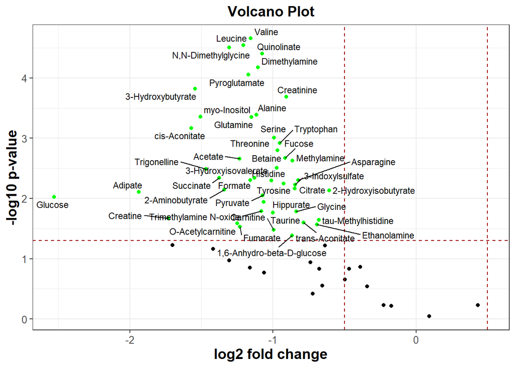

```r
plot_volcano(stats_metabolites, thres_pval= 0.05,thres_log2foldchange = 0.5, TRUE)
```

```r
sig_metabolites_kegg_id= map_keggid(sig_metabolites)
```

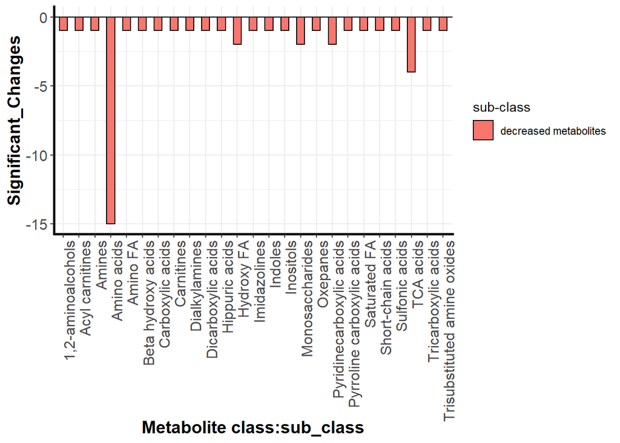

```r
count_changes = metcountplot(df_metclass=sig_metabolites_kegg_id, metclass='sub_class', plotting=TRUE, thres_logfC = 0.5)
count_changes$plotimg
```

```r
metenrichment = metclassenrichment(df_metclass=sig_metabolites_kegg_id, refmet_names, metclass= 'sub_class',enrich_stats="HG",no=1)
```

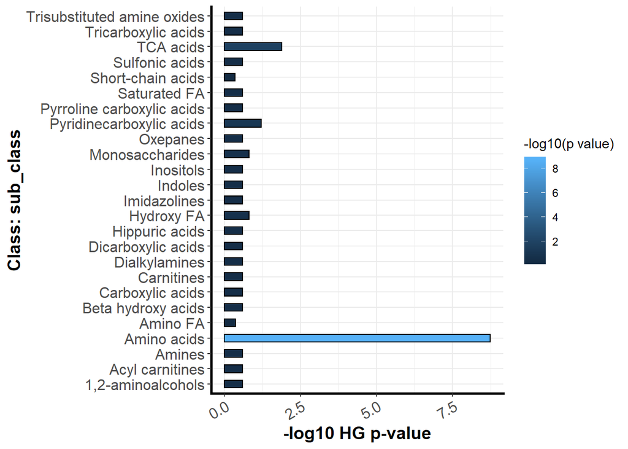

```r
plot_met_enrichment(metenrichment, metclass='sub_class',"HG", no=1)
```

The rest of the pipeline can be followed similarly.